# 樞紐定理與逆樞紐定理

> 來源整理：改國二下7_三角形的邊角關係_易讀版.md

## 樞紐定理：兩邊相等時，夾角越大第三邊越長

> 學習目標：樞紐定理比較的是兩個三角形：兩邊固定，夾角比較大，對面的第三邊也比較長。

### 先抓住核心

- 兩個三角形有兩組對應邊相等。
- 若其中一個三角形的夾角較大，則它的第三邊較長。
- 若夾角相等，則可用 SAS 判定全等，第三邊相等。
- 樞紐定理常用在共用邊、中線或兩邊相等的圖形中。
- 反向也常用：第三邊較長時，夾角較大。

### 解題流程

1. 確認兩個三角形有兩組對應邊相等。
2. 找出被這兩邊夾住的角。
3. 比較夾角大小。
4. 推出第三邊大小。
5. 若要反推角大小，使用逆樞紐定理。

### 公式、性質與判斷

- **樞紐定理**：兩邊相等時，夾角較大 -> 第三邊較長。
- **夾角相等**：SAS -> 第三邊相等。
- **逆樞紐**：第三邊較長 -> 夾角較大。

### 例題拆解

- 若 AB=DE、AC=DF 且 ∠A>∠D，則 BC>EF。
- 若 AD 共用、BD=CD 且 ∠2>∠1，則 AB>AC。
- 若 AB>AC 且 BD=CD、AD 共用，則 ∠BDA>∠CDA。

### 易錯提醒

- 沒有兩組對應邊相等就套樞紐定理。
- 比較的角不是夾角，導致結論錯誤。

### 小練一下

- 樞紐定理需要先確認哪兩種條件？
- 兩邊固定時，夾角變大，第三邊會怎樣？

### 記憶鉤子

- 樞紐像門鉸鏈：兩邊是門板，開口越大，兩端距離越遠。
- 先確認兩邊固定，再比較夾角。

### 圖像化理解

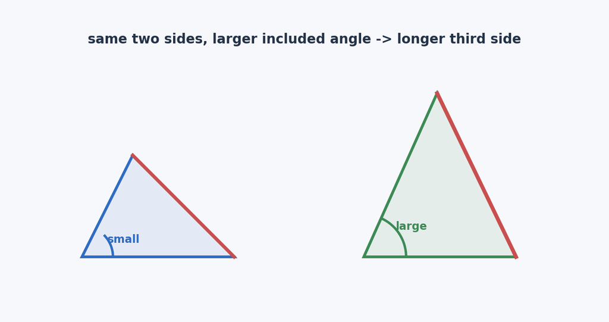

樞紐定理：兩邊相等時，夾角越大第三邊越長

## 中線、延長與邊角關係綜合

> 學習目標：中線題常把中點條件變成等邊，再搭配樞紐定理或三角形不等式。

### 先抓住核心

- 中線表示 D 是 BC 的中點，所以 BD=CD。
- 若 AD 是中線，兩個三角形 BAD 與 CAD 共用 AD。
- 若 AB>AC，可用逆樞紐定理得到 ∠BDA>∠CDA。
- 有些題目會在 AD 延長線上取 DE=AD，製造全等三角形。
- 利用三角形兩邊和大於第三邊，可推出 AB+AC > 2AD。

### 解題流程

1. 先把中線條件寫成 BD=CD。
2. 找共用邊 AD。
3. 用樞紐或逆樞紐比較角。
4. 若延長 AD 取 DE=AD，檢查可否形成全等三角形。
5. 最後用三角形不等式推出線段和關係。

### 公式、性質與判斷

- **中線**：BD=CD。
- **逆樞紐**：第三邊較長 -> 夾角較大。
- **常見不等式**：AB+AC > 2AD。

### 例題拆解

- 若 AB>AC 且 AD 是中線，則 ∠BDA>∠CDA。
- 在 AD 延長取 DE=AD，可製造 △ACD ≅ △EBD。
- 在 △ABE 中，AB+BE>AE，等價於 AB+AC>2AD。

### 易錯提醒

- 把中線當成角平分線或高，誤用角相等或垂直。
- 忘記延長構造後要說明全等理由。

### 小練一下

- AD 是 BC 上中線代表哪兩段相等？
- 三角形兩邊和與第三邊的關係是什麼？

### 記憶鉤子

- 中線題先找中點相等，再看能不能用樞紐或延長全等。
- 延長線常是為了把 2AD 做出來。

### 圖像化理解

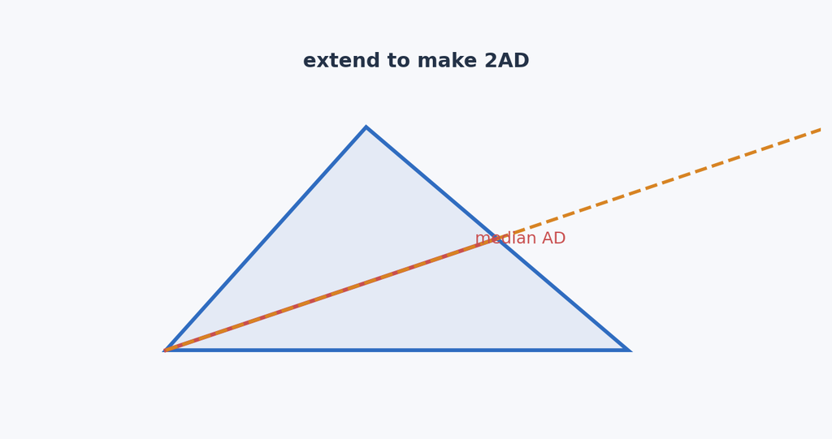

中線、延長與邊角關係綜合

圖解：示意中線 AD、延長 DE=AD 與 AB+AC>2AD 的關係。